# Data Visualisation in Python

This is a HTML document. The Introduction to Python course is written and intended to be used in a Jupyter Notebook file. These HTML documents have been made available for users who require screen readers or other accessibility needs. These HTML documents have been tested, but if you notice any errors or any compatibility issues please contact us on the GSS Capability email inbox.

If you are using a screen reader you will need to set your punctuation level (sometimes called verbosity) to full, especially for the code sections.

# Chapter 4 – Additional Plot Types

## Chapter Overview

- Packages and Data
- Pie Charts
- Violin Plots

# 1 Packages and Data

Let’s start, as always by loading our packages and our data.

We’re using:

- Numpy – Version 1.12.1
- Pandas – Version 0.20.1
- Matplotlib – Version 2.0.2
- Seaborn - Version 0.7.1

Remember you can use the .__version__ attribute (e.g np.__version__ )to check your version.

More information about the packages is given in Chapter 1.

We’re following standard convention for nicknames, and we’ll also load the gapminder data.

```python
 # Load packages
import pandas as pd
import matplotlib
import matplotlib.pyplot as plt
import numpy as np
import seaborn as sns
from matplotlib import rcParams # To set our defaults

# Load data
gapminder = pd.read_csv("../data/gapminder.csv")
```

# 2 Pie Charts

Pie charts are generally not a favoured type of visualisation. You should consider if a bar chart or a table is a better method of communicating your data.

If you do choose to use a pie chart, remember they should:

- have 6 or less categories. You may want to combine smaller categories if appropriate
- Rank the categories in a pie chart
- Start at the 12 o’clock position

Pie charts should always sum to 100%, if they do not then a pie chart is not appropriate.

Note that 3D Pie Charts and pie charts with a drop shadow are frowned upon even more so than ordinary pie charts and should be avoided at all cost.

For a pie chart we plot our x as the values we wish to plot. Matplotlib will automatically make this into a percentage of a whole, we don’t need to work our proportions out manually.

We’re also setting the start angle to be 90 and the direction to be clockwise (counterclock = False) to ensure we follow the guidance above.

```python
# Create our figure and our axes
figure, axes = plt.subplots(figsize=(6, 6))

gapminder_1992 = gapminder[gapminder["year"] == 1992]

number_countries = gapminder_1992.groupby(by = "continent", as_index= False)["country"].count()

number_countries.rename(columns = {"country": "num_countries"}, inplace= True) # Change the column name to be more descriptive

# Create a new dataframe - where the number of continents is sorted in descending order.
desc_number_countries = number_countries.sort_values(by = "num_countries", ascending=False).reset_index()

# Plot the Data
axes.pie(x=desc_number_countries["num_countries"], # NEW - use axes.pie
         startangle=90, # NEW - Sets the angle for the pie chart to start, 90 is at the 12 oclock position
         counterclock=False); # NEW - We wish to plot this data clockwise.


# Add Labels, Title and Captions
```

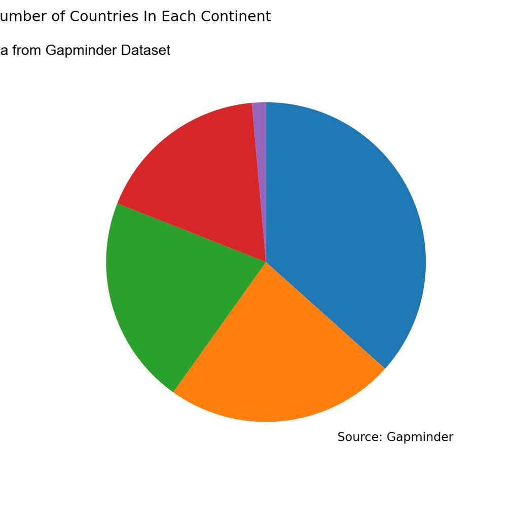

```python
plt.suptitle("Number of Countries In Each Continent", x = 0.25)
plt.title("Data from Gapminder Dataset" ,
          fontname="Arial", size=12, x = 0.02)
figure.text(x=0.65, y=0.15, s="Source: Gapminder", ha="left")

plt.show();
```

In these visualisations we’ve set our axis measurements to be even (6,6) – if we want to plot a pie chart on an uneven axis, e.g (6,4) we can add axes.axis(“equal”) to ensure our pie chart is round. This is especially useful when plotting multiple pie charts.

```python
# Create our figure and our axes
figure, axes = plt.subplots(figsize=(6, 4))

# Set the axis to be equal
axes.axis("equal") # No one likes a squished pie.

# Plot the Data
```

```python
axes.pie(x=desc_number_countries["num_countries"],
         startangle=90, # NEW - Sets the angle for the pie chart to start
         counterclock=False); # NEW - We wish to plot this data clockwise.


# Add Labels, Title and Captions
```

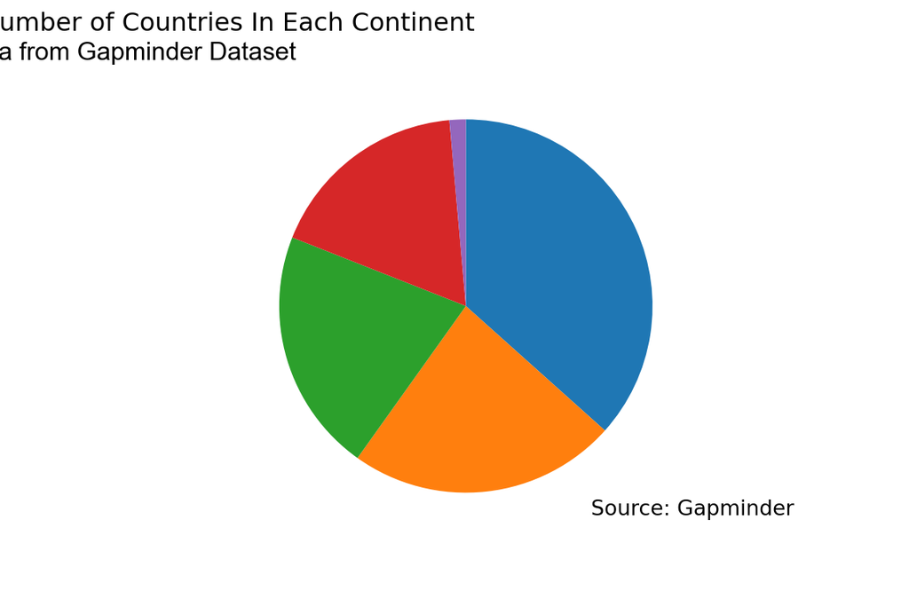

```python
plt.suptitle("Number of Countries In Each Continent", x = 0.25)
plt.title("Data from Gapminder Dataset" ,
          fontname="Arial", size=12, x = 0.02)
figure.text(x=0.65, y=0.15, s="Source: Gapminder", ha="left")

plt.show();
```

## 2.1 Labels

Our pie chart needs labels to be readable; we add these using the labels = parameter.

```python
# Create our figure and our axes
figure, axes = plt.subplots(figsize=(6, 6))

# Plot the Data
axes.pie(x=desc_number_countries["num_countries"],
         labels=desc_number_countries["continent"], # NEW - Add labels
         startangle=90, # Sets the angle for the pie chart to start
         counterclock=False); # We wish to plot this data clockwise.

# Add Labels, Title and Captions
```

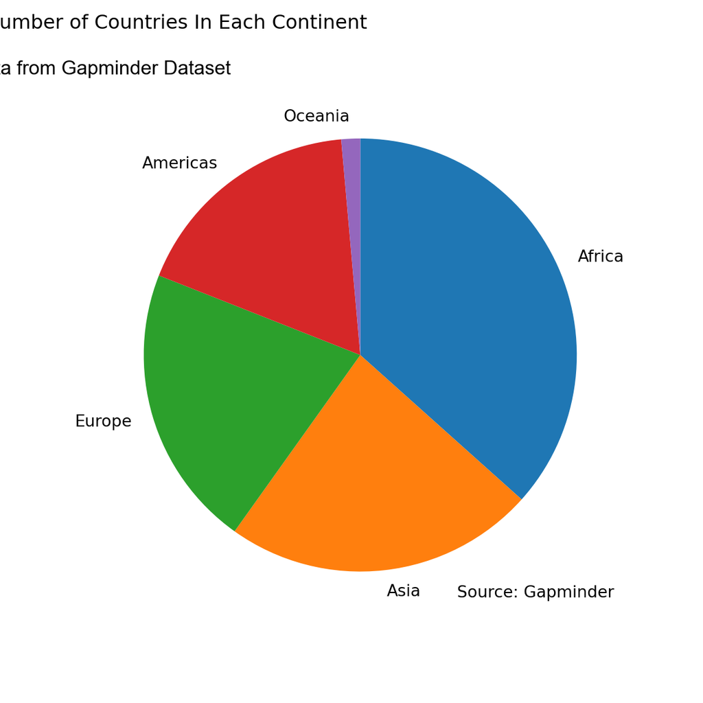

```python
plt.suptitle("Number of Countries In Each Continent", x = 0.25)
plt.title("Data from Gapminder Dataset" ,
          fontname="Arial", size=12, x = 0.02)
figure.text(x=0.65, y=0.15, s="Source: Gapminder", ha="left")

plt.show();
```

We can use the parameter textprops = to set how our text behaves on the pie chart.

```python
# Create our figure and our axes
figure, axes = plt.subplots(figsize=(6, 6))

# Plot the Data
axes.pie(x=desc_number_countries["num_countries"],
         labels=desc_number_countries["continent"], # NEW - Add labels
         startangle=90, # Sets the angle for the pie chart to start
         counterclock=False, # We wish to plot this data clockwise.
         textprops=dict(fontname = "Arial", color = "black", fontsize = 12, multialignment = "center") )

# Add Labels, Title and Captions
```

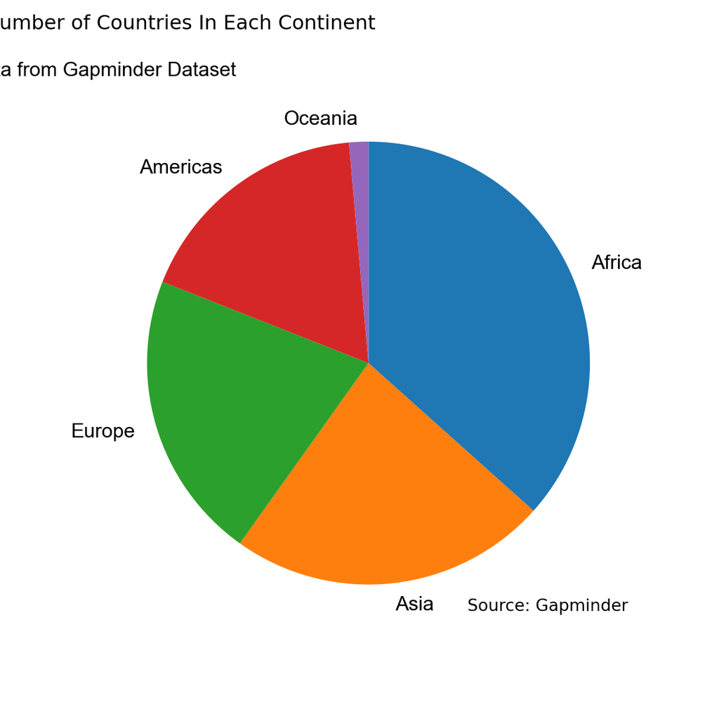

```python
plt.suptitle("Number of Countries In Each Continent", x = 0.25)
plt.title("Data from Gapminder Dataset" ,
          fontname="Arial", size=12, x = 0.02)
figure.text(x=0.65, y=0.15, s="Source: Gapminder", ha="left")

plt.show();
```

## 2.2 Percentages

We can also get matplotlib to calculate our percentages. We do this with the autopct parameter. This uses string formatting.

- The first % symbol indicates we want to work out a percentage.
- The 0.2 indicates the number of decimal points, here 2.
- The two %% symbols show the % symbol on the chart.

```python
# Create our figure and our axes
figure, axes = plt.subplots(figsize=(6, 6))

# Plot the Data
axes.pie(x=desc_number_countries["num_countries"],
         labels=desc_number_countries["continent"], #  Add labels
         startangle=90, # Sets the angle for the pie chart to start
         counterclock=False, # We wish to plot this data clockwise.
         autopct="%0.2f%%" , # NEW Add the % symbol
         textprops=dict(fontname = "Arial", color = "black", fontsize = 12, multialignment = "center") )

# Add Labels, Title and Captions
```

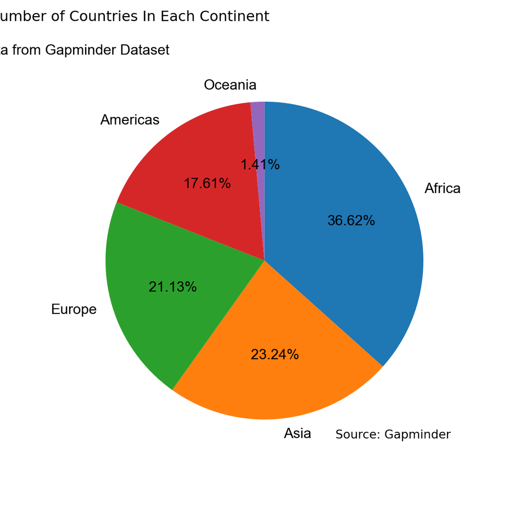

```python
plt.suptitle("Number of Countries In Each Continent", x = 0.25)
plt.title("Data from Gapminder Dataset" ,
          fontname="Arial", size=12, x = 0.02)
figure.text(x=0.65, y=0.15, s="Source: Gapminder", ha="left")

plt.show();
```

We can use the parameter pctdistance to move the percentage symbols. 1 is on the edge of the pie chart and 0 is in the centre.

```python
# Create our figure and our axes
figure, axes = plt.subplots(figsize=(6, 6))

# Plot the Data
axes.pie(x=desc_number_countries["num_countries"],
         labels=desc_number_countries["continent"], #  Add labels
         startangle=90, # Sets the angle for the pie chart to start
         counterclock=False, # We wish to plot this data clockwise.
         textprops=dict(fontname = "Arial", color = "black", fontsize = 12, multialignment = "center"),
         autopct="%0.2f%%",
         pctdistance=0.9) # NEW move the %

# Add Labels, Title and Captions
```

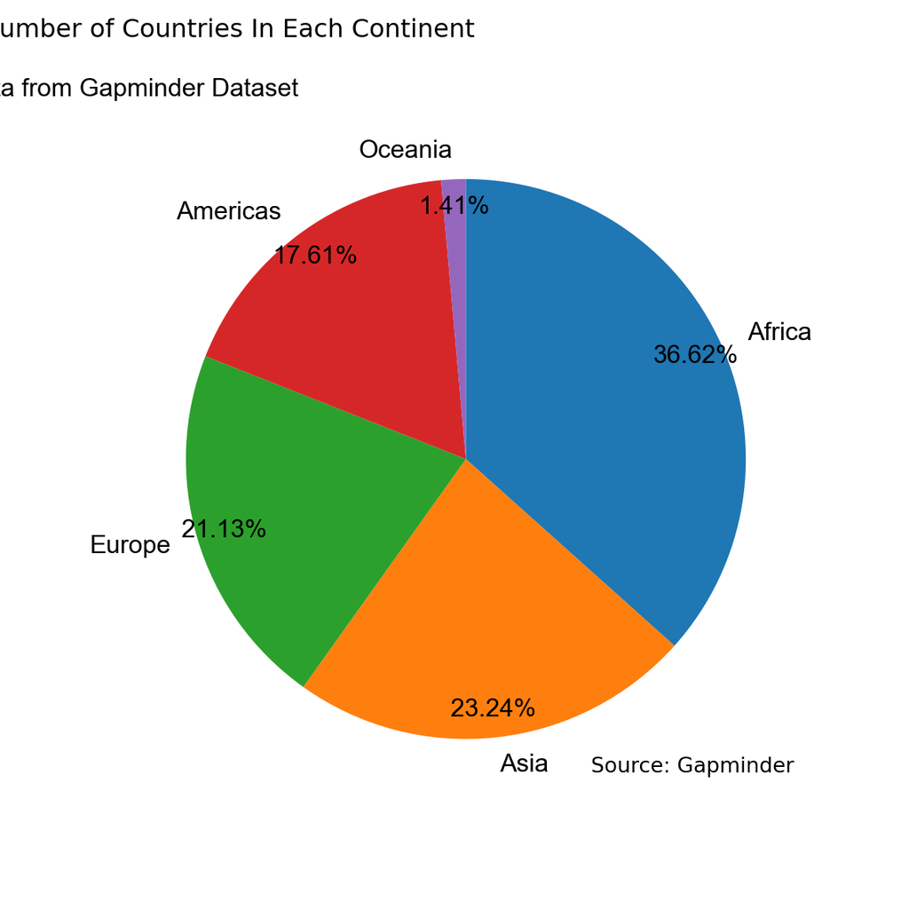

```python
plt.suptitle("Number of Countries In Each Continent", x = 0.25)
plt.title("Data from Gapminder Dataset" ,
          fontname="Arial", size=12, x = 0.02)
figure.text(x=0.65, y=0.15, s="Source: Gapminder", ha="left")

plt.show();
```

You can also give a number greater than 1 to move the % outside of the pie chart; we also have labeldistance which allows us to move the labels.

```python
# Create our figure and our axes
figure, axes = plt.subplots(figsize=(6, 6))

# Plot the Data
axes.pie(x=desc_number_countries["num_countries"],
         labels=desc_number_countries["continent"], #  Add labels
         startangle=90, # Sets the angle for the pie chart to start
         counterclock=False, # We wish to plot this data clockwise.
         textprops=dict(fontname = "Arial", color = "black", fontsize = 12, multialignment = "center"),
         autopct="%0.2f%%",
         pctdistance=1.15,
         labeldistance= 1.3); # NEW move the labels

# Add Labels, Title and Captions
```

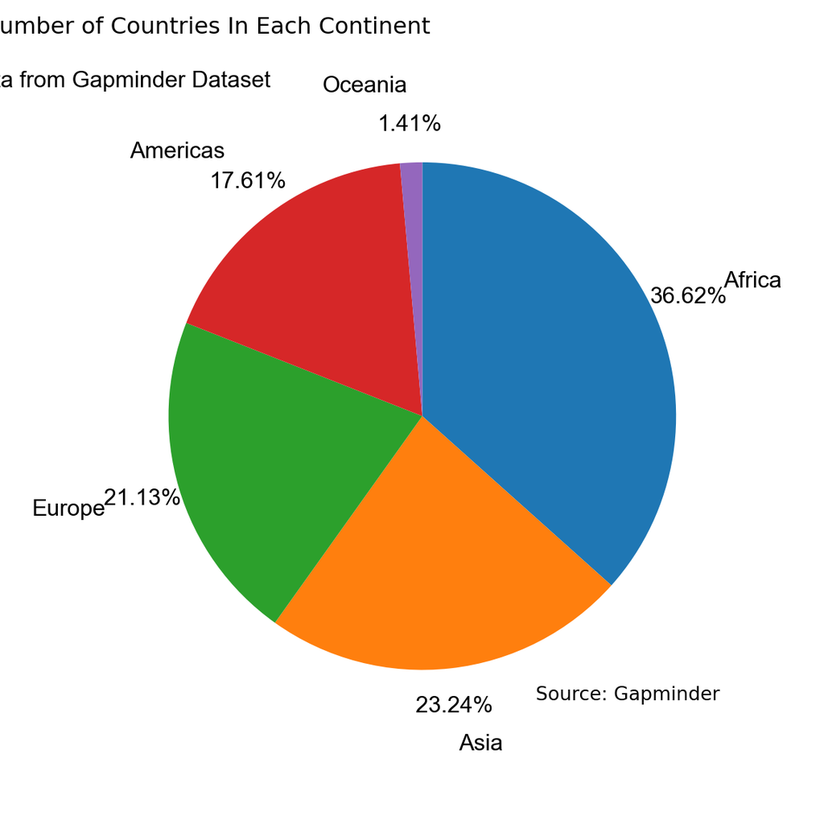

```python
plt.suptitle("Number of Countries In Each Continent", x = 0.25)
plt.title("Data from Gapminder Dataset" ,
          fontname="Arial", size=12, x = 0.02)
figure.text(x=0.65, y=0.15, s="Source: Gapminder", ha="left")

plt.show();
```

We can also use a short lambda anonymous function to display the number of values on the pie chart as well as the percentages.

Geeks for Geeks has a good [tutorial](https://www.geeksforgeeks.org/python-lambda-anonymous-functions-filter-map-reduce/) if you’ve not seen lambda functions before.

```python
# Create our figure and our axes
figure, axes = plt.subplots(figsize=(6, 6))

# Plot the Data
axes.pie(x = desc_number_countries["num_countries"],
         labels = desc_number_countries["continent"], #  Add labels
         startangle=90, # Sets the angle for the pie chart to start
         counterclock = False, # Plot data clockwise
         textprops=dict(fontname = "Arial", color = "black", fontsize = 12, multialignment = "center"),
         autopct=lambda p: '{:.2f}%\n({:.0f})'.format(p,(p/100)*desc_number_countries["num_countries"].sum()),
         # Adds in the number values of each continent.
         pctdistance = 1.2, # Moves the values out slightly
         labeldistance= 1.4 ) # Moves the labels


# Add Labels, Title and Captions
```

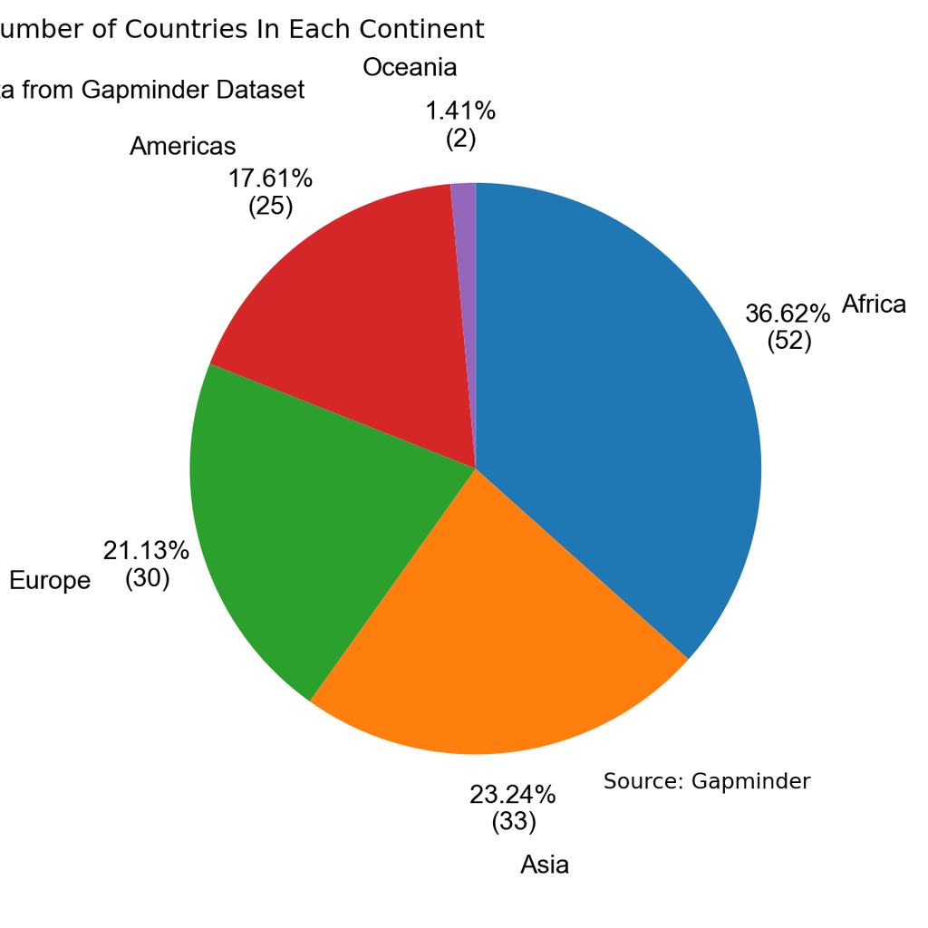

```python
plt.suptitle("Number of Countries In Each Continent", x = 0.25)
plt.title("Data from Gapminder Dataset" ,
          fontname="Arial", size=12, x = 0.02)
figure.text(x=0.65, y=0.15, s="Source: Gapminder", ha="left")

plt.show();
```

### 2.2.1 Labels and Percentages

When we set the parameters labels and autopct the location of both is controlled independently.

You can see in the visualisation above that this can cause problems and be generally a bit unappealing. You may be able to pair up one label and percentage correctly, but struggle with the others.

There’s two main ways we can solve this:

1. Set a legend
2. Manually create our own labels.

We set a legend using the axes.legend() method.

It’s important to note here that we don’t use the labels parameter, instead passing our labels to the legend directly.

This method has drawbacks as it can take longer to identify which colour belongs to which continent, but it is slightly easier to code than the other method.

```python
# Create our figure and our axes
figure, axes = plt.subplots(figsize=(6, 6))

# Plot the Data
axes.pie(x=desc_number_countries["num_countries"],
         startangle=90, # Sets the angle for the pie chart to start
         counterclock=False, # Plot data clockwise
         autopct=lambda p: '{:.2f}%\n({:.0f})'.format(p,(p/100)*desc_number_countries["num_countries"].sum()),
         # Adds in the number values of each continent.
         pctdistance=0.8) # Moves the values out slightly


# Add Labels, Title and Captions
```

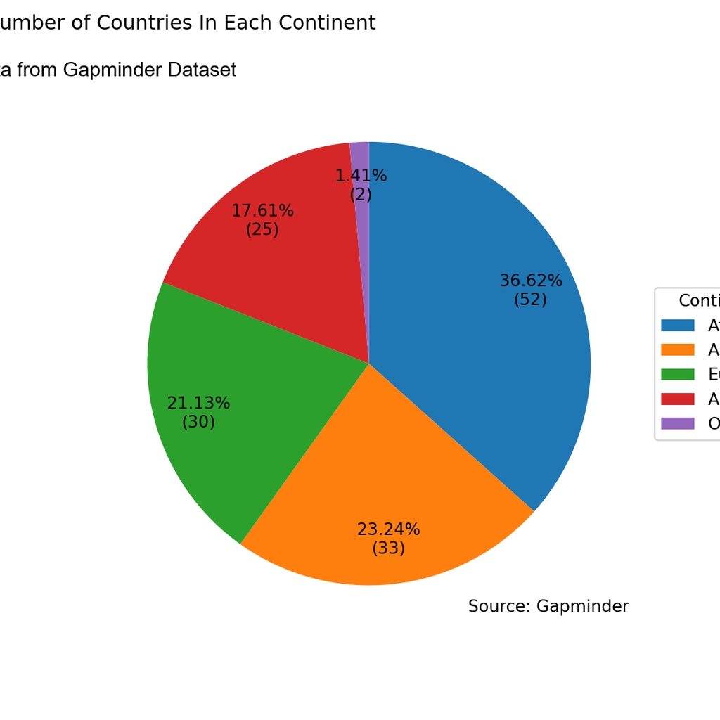

```python
plt.suptitle("Number of Countries In Each Continent", x = 0.25)
plt.title("Data from Gapminder Dataset" ,
          fontname="Arial", size=12, x = 0.02)
figure.text(x=0.65, y=0.15, s="Source: Gapminder", ha="left")

# Create a Legend
axes.legend(desc_number_countries["continent"],
            title="Continents",
            loc="center left",
            bbox_to_anchor=(1, 0, 0.5, 1))

plt.show();
```

The labels parameter can take a list of values. So far we’ve let Matplotlib automatically generate this list for us; but we can have finer control if we create it ourselves. Our labels will include:

- Name
- Count
- Percentage

To obtain them we loop over each of our countries in turn and create a new list with these values, using formatting strings. This returns us a list with the same number of arguments as wedges in our pie – in this case 5.

Here we’re using string formatting using .format(). This may be new to you, but is a useful tool to know how to use. [PyFormat’s tutorial](https://pyformat.info/) may be useful to read.

```python
# Create a new blank list for our new labels
labels_continents = []
# Loop through each continent to get the
for each_cont in desc_number_countries["continent"]:
    labels_continents.append("{}\n{:.0f}\n{:.2f}%".format( # Format our output
       each_cont, # Name
       list(desc_number_countries[desc_number_countries["continent"] == each_cont]["num_countries"])[0],# Number of entries
       list(desc_number_countries[desc_number_countries["continent"] == each_cont]["num_countries"])[0] / desc_number_countries["num_countries"].sum() * 100))
       # Percentage

labels_continents # Have a look at the output of our loop
```

```
['Africa\n52\n36.62%', 'Asia\n33\n23.24%', 'Europe\n30\n21.13%', 'Americas\n25\n17.61%', 'Oceania\n2\n1.41%']
```

We can apply this to our pie chart, we can use the parameters labeldistance to control the distance from the plot, and the parameter textprops to fine tune our text.

```python
# Set Up - Create Custom labels

# Create a new blank list for our new labels
labels_continents = []
# Loop through each continent to get the
for each_cont in desc_number_countries["continent"]:
    labels_continents.append("{}\n{:.0f}\n{:.2f}%".format( # Format our output
       each_cont, # Name
       list(desc_number_countries[desc_number_countries["continent"] == each_cont]["num_countries"])[0],# Number of entries
       list(desc_number_countries[desc_number_countries["continent"] == each_cont]["num_countries"])[0] / desc_number_countries["num_countries"].sum() * 100))
       # Percentage

# Create our figure and our axes
figure, axes = plt.subplots(figsize=(6, 6))

# Plot the Data
axes.pie(x=desc_number_countries["num_countries"],
         startangle=90, # Sets the angle for the pie chart to start
         counterclock=False, # Plot data clockwise
         labels=labels_continents, # Use our newly defined labels
         labeldistance=1.2, # Moves the values out slightly
         textprops=dict(fontname = "Arial",
                        color = "black",
                        fontsize = 12,
                        multialignment = "left"))


# Add Labels, Title and Captions
```

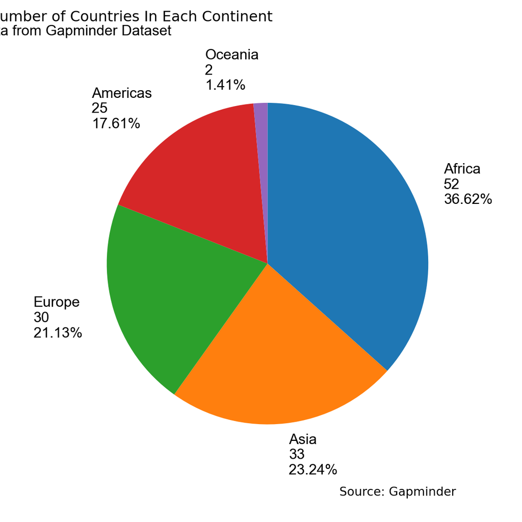

```python
plt.suptitle("Number of Countries In Each Continent", x = 0.25)
plt.title("Data from Gapminder Dataset" ,
          fontname="Arial", size=12, x = 0.02, y = 1.05)
figure.text(x=0.65, y=0.05, s="Source: Gapminder", ha="left")

plt.show();
```

## 2.3 Colours

Again, we won’t go through all of the colour options here; as these are covered in chapter 2.

We can create a list of colours we wish to use. This will apply in the order of the list, and in a clockwise direction - as counterclock is set to False.

```python
# Set a list of colours to use
colour_list = ["#845EC2", "#00C9A7",  "#C4FCEF",  "#4D8076", "#FF8066"]

# Create our figure and our axes
figure, axes = plt.subplots(figsize=(6, 6))

# Plot the Data
axes.pie(x=desc_number_countries["num_countries"],
         labels=desc_number_countries["continent"],
         startangle=90,
         counterclock=False,
         autopct="%0.2f%%",
         pctdistance=0.8,
         colors=colour_list)

# Add Labels, Title and Captions
```

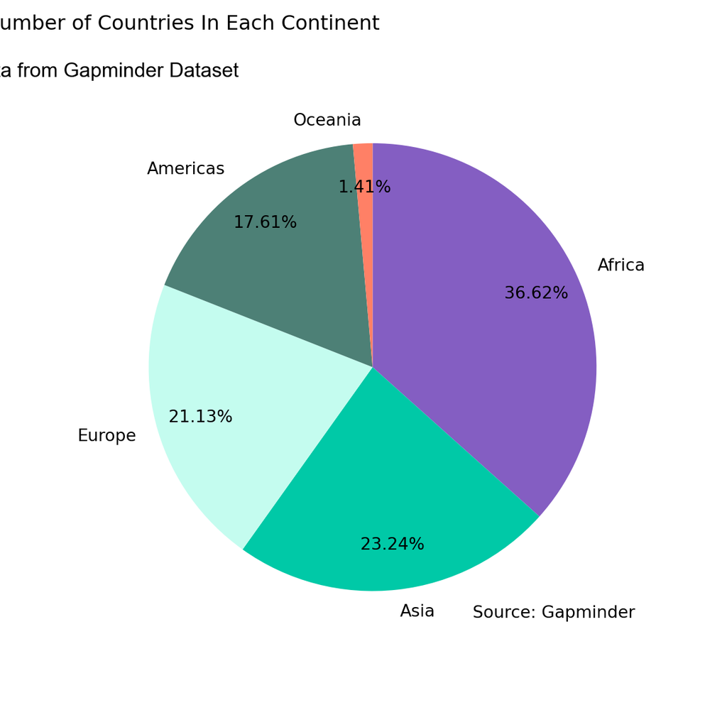

```python
plt.suptitle("Number of Countries In Each Continent", x = 0.25)
plt.title("Data from Gapminder Dataset" ,
          fontname="Arial", size=12, x = 0.02)
figure.text(x=0.65, y=0.15, s="Source: Gapminder", ha="left")

plt.show();
```

## 2.4 Exploding Segments

Exploding segments of a pie chart is again, not considered best practice.

We can set a parameter explode which takes a list of numbers. The list has the same number of items as our pie chart has segments. In this visualisation these again apply in a clockwise direction (because counterclock = False ).

If the number corresponding to that segment is greater than 0 it is “exploded” from the pie chart. Typically this is a decimal number, e.g the 0.3 for the Africa segment; however it can take an integer for an extreme “explosion” from the chart.

```python
# Set a list of colours to use
colour_list = ["#845EC2", "#00C9A7",  "#C4FCEF",  "#4D8076", "#FF8066"]

# Create our figure and our axes
figure, axes = plt.subplots(figsize=(6, 6))

# Plot the Data
axes.pie(x=desc_number_countries["num_countries"],
         labels=desc_number_countries["continent"],
         startangle=90,
         counterclock=False,
         autopct="%0.2f%%",
         pctdistance=0.8,
         colors=colour_list,
         explode=[0.3,0,0,0,0])

# Add Labels, Title and Captions
```

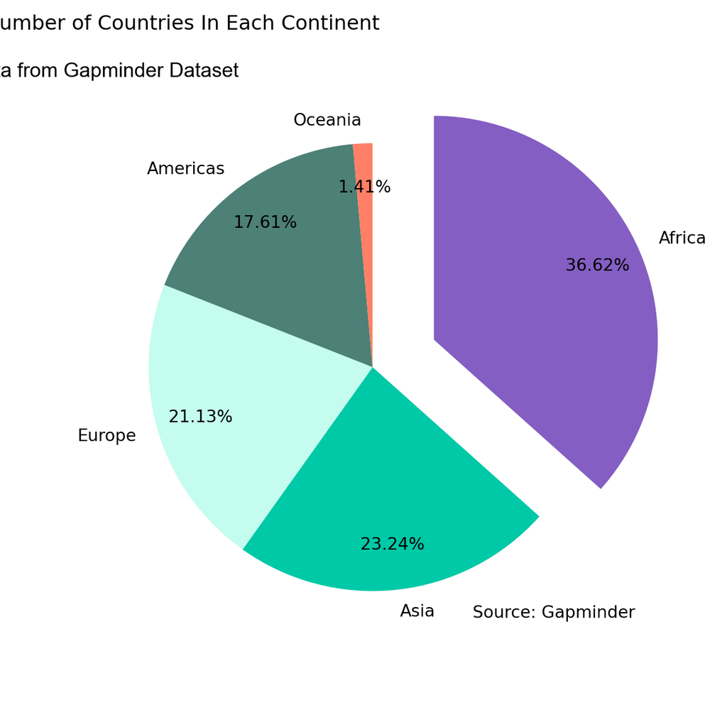

```python
plt.suptitle("Number of Countries In Each Continent", x = 0.25)
plt.title("Data from Gapminder Dataset" ,
          fontname="Arial", size=12, x = 0.02)
figure.text(x=0.65, y=0.15, s="Source: Gapminder", ha="left")

plt.show();
```

## 2.5 Donut Charts

> “Donuts. Is there anything they can’t do?” *Homer Simpson*

Donut plots are generally considered superior to pie charts. This isn’t to say that they’re recommended over other ways of displaying your data; but if you do need to use something in the Pie Chart family, this would be our recommendation. This is because the white space in the middle makes it easier for the human eye to determine the proportions.

We can set the paramater wedgeprops and pass to it a dictionary. This alows us to control the wedges, we can also set linestyles, hatching and other [parameters](https://matplotlib.org/stable/api/_as_gen/matplotlib.patches.Wedge.html) in this dictionary.

```python
# Set up the colours
colour_list = ["#845EC2", "#00C9A7", "#C4FCEF", "#4D8076", "#FF8066"]

# Create our figure and our axes
figure, axes = plt.subplots(figsize=(6, 6))

# Plot the Data
axes.pie(x=desc_number_countries["num_countries"],
         labels=desc_number_countries["continent"],
         startangle=90,
         counterclock=False,
         autopct="%0.2f%%",
         pctdistance=0.8,
         colors=colour_list,
         wedgeprops=dict(width=0.5))

# Add Labels, Title and Captions
```

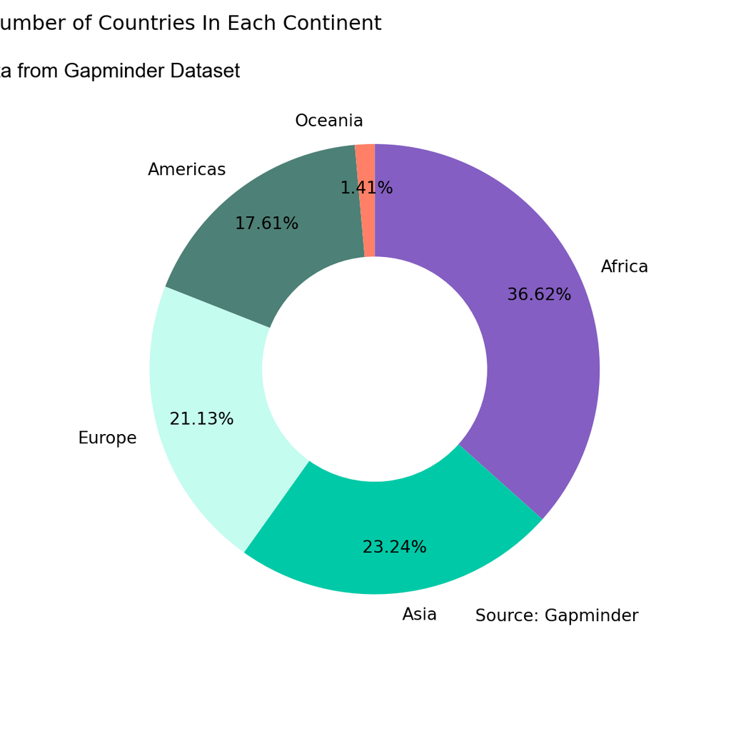

```python
plt.suptitle("Number of Countries In Each Continent", x = 0.25)
plt.title("Data from Gapminder Dataset" ,
          fontname="Arial", size=12, x = 0.02)
figure.text(x=0.65, y=0.15, s="Source: Gapminder", ha="left")

plt.show();
```

Alternatively we create a donut chart by first creating a pie chart, then by creating a white circle and overlaying that on our pie chart.

In this section we’re creating something known as a patch, an artist object. These can be used for a wide variety of things, including fine tuning images. We feel they’re slightly beyond the scope of this course, but you can find more information in the [matplotlib documentation](https://matplotlib.org/stable/api/_as_gen/matplotlib.patches.Circle.html) if you should require it.

Importantly we can alter the radius = parameter to set the size of the inner circle, and you can change the colour if you have your plot on a different coloured background; although this is not advised.

```python
# Set up the colours
colour_list = ["#845EC2", "#00C9A7", "#C4FCEF", "#4D8076", "#FF8066"]

# Create our figure and our axes
figure, axes = plt.subplots(figsize=(6, 6))

# Plot the Data
axes.pie(x=desc_number_countries["num_countries"],
         labels=desc_number_countries["continent"],
         startangle=90,
         counterclock=False,
         autopct="%0.2f%%",
         pctdistance=0.8,
         colors=colour_list);

# NEW - Create a circle that overlays the Pie Chart
```

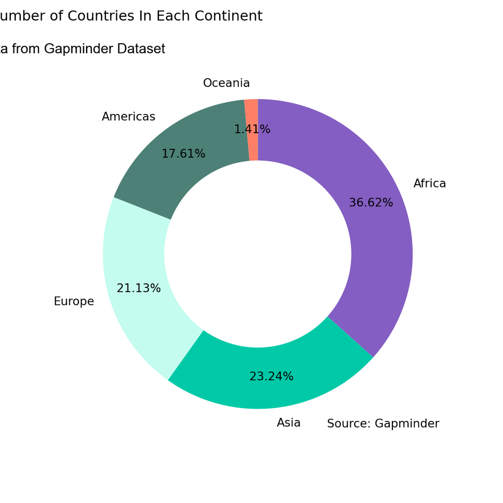

```python
my_circle=plt.Circle((0,0), radius = 0.6, color="white")
p=plt.gcf()
p.gca().add_artist(my_circle);


# Add Labels, Title and Captions
plt.suptitle("Number of Countries In Each Continent", x = 0.25)
plt.title("Data from Gapminder Dataset" ,
          fontname="Arial", size=12, x = 0.02)
figure.text(x=0.65, y=0.15, s="Source: Gapminder", ha="left")

plt.show();
```

# 3 Violin Plots

Again, like box plots, violin plots are included because they are sometimes used in exploratory analysis.

People either love or hate violin plots, but we’ve included them for completeness.

```python
# Set up the figure and axis
figure, axes = plt.subplots(figsize=(6, 5))

# Make our 1987 data again
gm_1987 = gapminder[gapminder["year"] == 1987]

# Remove the null values before plotting
life_exp = gm_1987[ gm_1987["life_exp"].notnull()]["life_exp"]

# Plot the violin plot
violin_parts = axes.violinplot(life_exp.values,
                               showmeans = True,
                               showextrema = True,
                               showmedians = True)

# Set Gridlines and colours
axes.grid(b = True, axis = "x", c = "white", which = "major")
```

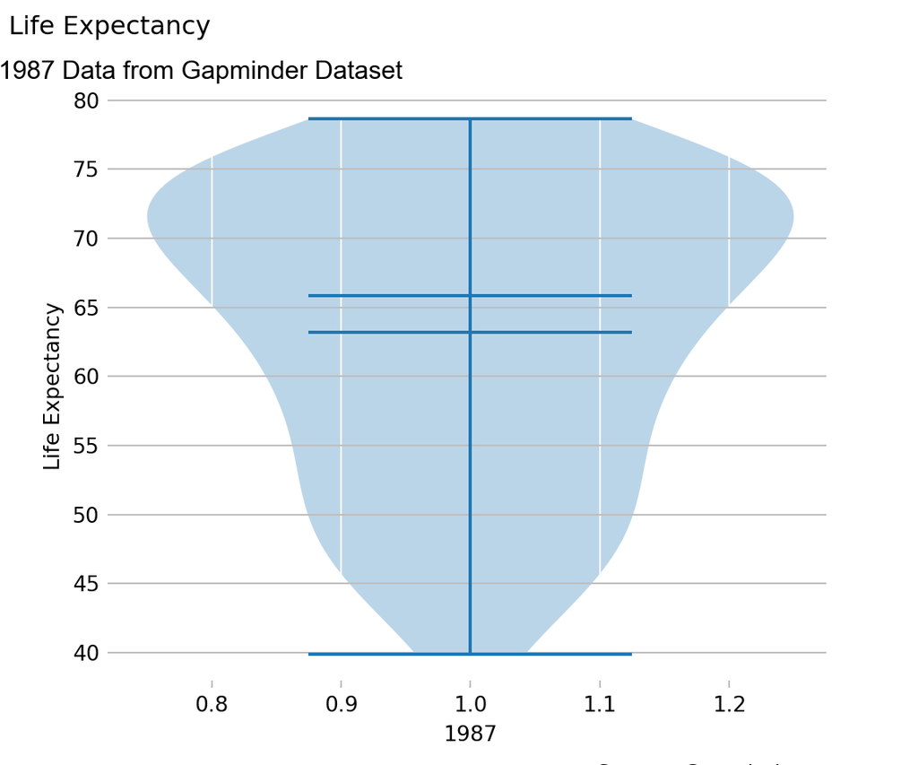

```python
axes.grid(b = True, axis = "y", c = (0.745, 0.745, 0.745), which = "major")
axes.set_frame_on(False)

# Add Labels, Title and Captions
plt.suptitle("Life Expectancy", x = 0.12)
plt.title("1987 Data from Gapminder Dataset" ,
          fontname = "Arial", size = 12, x = 0.12)

figure.text(x=0.65, y=-0.02, s="Source: Gapminder", ha="left")
axes.set_ylabel("Life Expectancy")
axes.set_xlabel("1987")
axes.grid(b = True, which = "major", axis = "y", color = (0.745, 0.745, 0.745))
axes.set_frame_on(False)

# Set Tick Colours to the same grey as our gridlines
axes.xaxis.set_tick_params(color=(0.745,0.745,0.745))
axes.yaxis.set_tick_params(color=(0.745,0.745,0.745))

plt.show();
```

We can also use Seaborn’s sns.violinplot() method.

```python
# Set up the figure and axis
figure, axes = plt.subplots(figsize=(5,5))

# Plot
violin_plot = sns.violinplot(y = "life_exp",
                             data = gm_1987)

# Removes the "spines" or edges of our vis
sns.despine(left=True, bottom=True)

# Add Labels, Title and Captions (this comes from Matplotlib!)
plt.suptitle("Life Expectancy", x = 0.22, y = 1., fontname="Arial", size=16,)
plt.title("1987 Data from Gapminder Dataset" ,
          fontname = "Arial", size = 12, x = 0.23, y = 1.05)

plt.text(x=0, y= 20, s="Source: Gapminder", ha="left")
violin_plot.set_ylabel("Life Expectancy (years)")
violin_plot.set_xlabel("1987")

# Set Gridlines and colours
violin_plot.grid(b = True , which = "both", axis = "y", color = (0.745, 0.745, 0.745))

# Set Tick Colours to the same grey as our gridlines
```

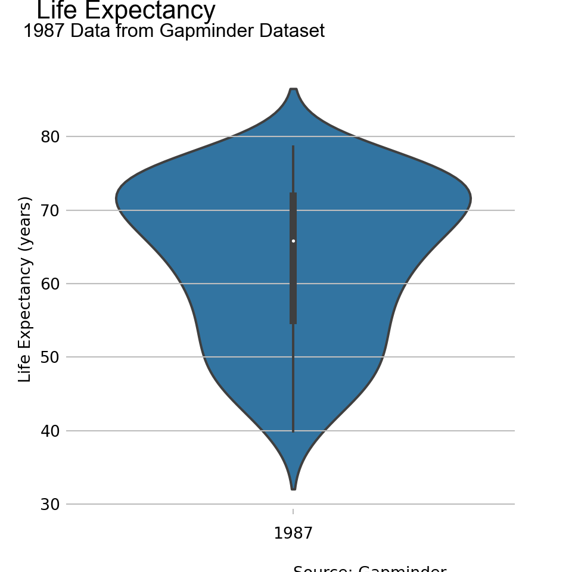

```python
violin_plot.xaxis.set_tick_params(color=(0.745,0.745,0.745))
violin_plot.yaxis.set_tick_params(color=(0.745,0.745,0.745))

plt.show();
```